# Netflix Data Analysis

2024-09-05

## NETFLIX DATA ANALYSIS

### Introduzione

#### Questa analisi mira ad esporre quanto segue:

1. Andamento del fatturato globale di Netflix e degli abbonamenti nelle diverse regioni
2. Mostrare i ricavi per utente (RPU) nelle diverse regioni.
3. Confrontare le prestazioni nazionali e internazionali nel tempo
4. Per mostrare gli utenti globali nel tempo

## Data Overview

Il dataset in questione (reperito su Kaggle) fornisce dati di diverso tipo sull’andamento dell’azienda Netflix nel corso degli anni, prendendo in considerazione 4 regioni specifiche:

UCAN : Stati Uniti e Canada EMEA : Europa, Medio Oriente e Africa APAC : Asia-Pacifico LATM : America Latina

## ANALISI DEI TREND - Fatturato globale nel tempo

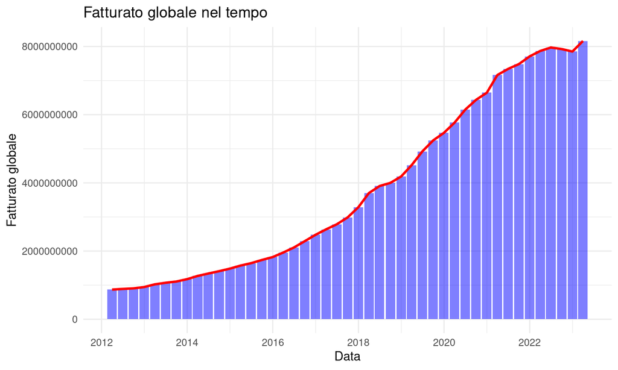

## Analisi delle tendenze - Fatturato globale nel tempo

Osservazioni chiave:

1. L’aumento costante del fatturato globale nel corso degli anni indica una forte crescita.
2. Esiste una traiettoria costante verso l’alto delle entrate annuali.

Linea di tendenza:

1. La linea di tendenza rossa sovrapposta alle barre evidenzia una graduale accelerazione dei ricavi, particolarmente evidente a partire dal 2016 circa.
2. I dati più recenti, in particolare quelli relativi al periodo 2021-2023, indicano che il tasso di aumento potrebbe stabilizzarsi.

## ANALISI DEL TREND - Entrate regionali nel tempo

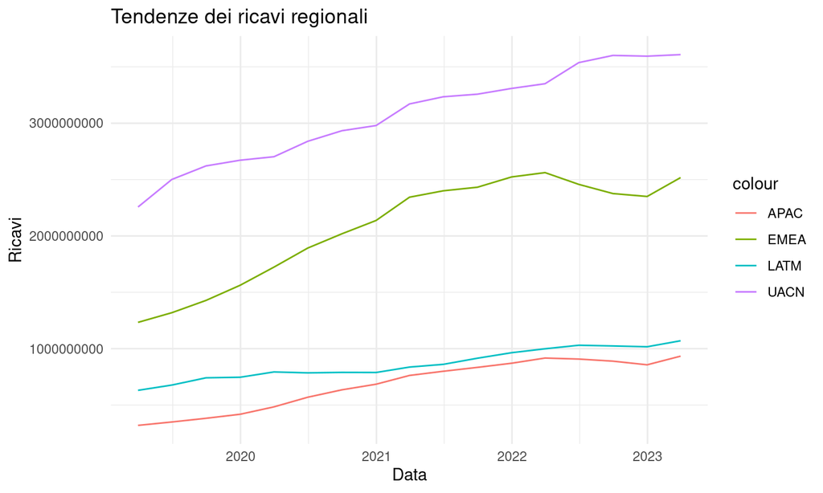